# General introduction to YAXArrays.jl and xmap

Authors

Affiliations

Felix Cremer

Max Planck Institute for Biogeochemistry

Lazaro Alonso

Max Planck Institute for Biogeochemistry

Anshul Singhvi

JuliaHub

Fabian Gans

Max Planck Institute for Biogeochemistry

```julia
using Pkg
# Pkg.offline()
Pkg.activate(".")
Pkg.instantiate()
Pkg.add(url="https://github.com/meggart/DiskArrayEngine.jl.git", rev="main")
Pkg.add(url="https://github.com/JuliaDataCubes/YAXArrays.jl.git", rev="master")
```

[output not shown]

[output cut: 1486 more lines]

[output not shown]

```julia
import Makie: create_dim_conversion

create_dim_conversion(union_typ::Type{Union{Missing,T}}) where {T<:Real} =
    create_dim_conversion(union_typ.b)
```

```
create_dim_conversion (generic function with 6 methods)
```

```julia
using DimensionalData, YAXArrays, Zarr, NetCDF
using CairoMakie
```

```julia
bucket = "esdl-esdc-v3.0.2"
store = "esdc-16d-2.5deg-46x72x1440-3.0.2.zarr"
bucketpath = "https://s3.bgc-jena.mpg.de:9000/" * bucket * "/" * store
path = joinpath(homedir(), "Daten/") * "bids2025_" * store
ds = open_dataset(zopen(bucketpath,consolidated=true,fill_as_missing=true))
c = Cube(ds)

#c = Cube(joinpath(tutorialdir,"esdc_subset2.zarr"))
```

```
┌ 144×72×989×42 YAXArray{Union{Missing, Float32}, 4} ┐
├────────────────────────────────────────────────────┴─────────────────── dims ┐
  ↓ lon Sampled{Float64} -178.75:2.5:178.75 ForwardOrdered Regular Points,
  → lat Sampled{Float64} -88.75:2.5:88.75 ForwardOrdered Regular Points,
  ↗ time Sampled{Dates.DateTime} [Dates.DateTime("1979-01-09T00:00:00"), …, Dates.DateTime("2021-12-27T00:00:00")] ForwardOrdered Irregular Points,
  ⬔ Variables Categorical{String} ["sensible_heat", …, "snow_sublimation"] Unordered
├──────────────────────────────────────────────────────────────────── metadata ┤
  Dict{String, Any} with 30 entries:
  "original_add_offset"       => 0.0
  "time_coverage_end"         => "2021-12-31T00:00:00.000000000"
  "geospatial_lat_resolution" => -0.25
  "time_coverage_start"       => "1980-01-05T00:00:00.000000000"
  "wavelength_units"          => "nm"
  "standard_name"             => "snow_sublimation"
  "processing_steps"          => Any["Merging nc files", "resampling by 8-day m…
  "bandwidth_units"           => "nm"
  "temporal_resolution"       => "8D"
  "_FillValue"                => NaN
  "units"                     => "mm d^-1"
  "geospatial_lon_max"        => 179.875
  "wavelength"                => 858.5
  "source"                    => Any["GLEAM v3.6a", "https://www.gleam.eu/"]
  "original_scale_factor"     => 1.0
  "long_name"                 => "Snow Sublimation"
  "bandwidth"                 => 35.0
  "acknowledgment"            => "https://www.gleam.eu/"
  "reported_day"              => 5.0
  ⋮                           => ⋮
├─────────────────────────────────────────────────────────────── loaded lazily ┤
  data size: 1.6 GB
└──────────────────────────────────────────────────────────────────────────────┘
```

## 1 The `mapCube` function

is a generalization of mapslices, where you can annotate the exact signature of the function to be applied. For example the computation of the `median` over time can be written using `mapCube`. Here one hase to specify the dimension(s) that the user-defined function is going to operate on. For the computation of the median over time the only input dimension is `time` and there are no output dimensions as only a single value is returned. The user defined function passed to `mapCube` always has the signature `f(outputs..., inputs...)` and potentially followd by additional arguments and keyword args.

## 2 Apply function along single Axis

```julia
using Statistics
function apply_median(xout, xin)
    x = filter(!ismissing, xin)
    x = filter(!isnan,x)
    xout[] = isempty(x) ? missing : median(x)
end
```

```
apply_median (generic function with 1 method)
```

```julia
medians = xmap(apply_median, c[Variable=Where(contains("temp"))] ⊘ :time)
```

```
┌ 144×72×1×3 YAXArray{Union{Missing, Float32}, 4} ┐
├─────────────────────────────────────────────────┴────────────────────── dims ┐
  ↓ lon Sampled{Float64} -178.75:2.5:178.75 ForwardOrdered Regular Points,
  → lat Sampled{Float64} -88.75:2.5:88.75 ForwardOrdered Regular Points,
  ↗ time Sampled{IntervalSets.ClosedInterval{Dates.DateTime}} [1979-01-09T00:00:00 .. 2021-12-27T00:00:00] ForwardOrdered Irregular Intervals{Start},
  ⬔ Variables Categorical{String} ["max_air_temperature_2m", …, "min_air_temperature_2m"] Unordered
├─────────────────────────────────────────────────────────────── loaded lazily ┤
  data size: 121.5 KB
└──────────────────────────────────────────────────────────────────────────────┘
```

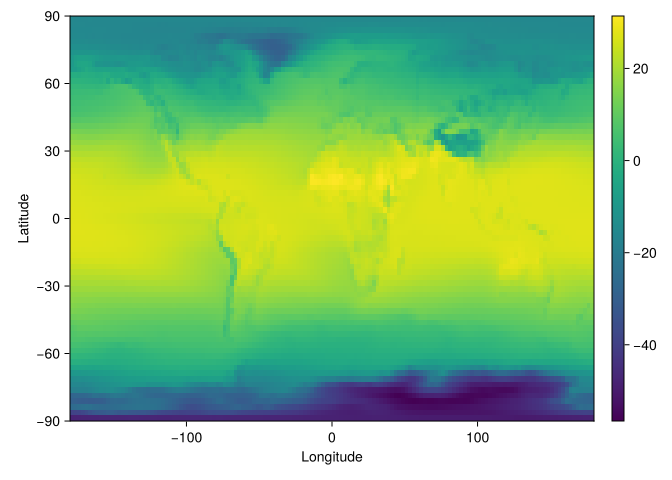

```julia
fig, ax, heat = heatmap(medians[Variable=At("air_temperature_2m"), time=1]);
colorbar = Colorbar(fig[1,2], heat)
fig
```

## 3 Apply function on all elements

```julia
medians_kelvin = medians .+ 273.15
```

```
┌ 144×72×1×3 YAXArray{Union{Missing, Float32}, 4} ┐
├─────────────────────────────────────────────────┴────────────────────── dims ┐
  ↓ lon Sampled{Float64} -178.75:2.5:178.75 ForwardOrdered Regular Points,
  → lat Sampled{Float64} -88.75:2.5:88.75 ForwardOrdered Regular Points,
  ↗ time Sampled{IntervalSets.ClosedInterval{Dates.DateTime}} [1979-01-09T00:00:00 .. 2021-12-27T00:00:00] ForwardOrdered Irregular Intervals{Start},
  ⬔ Variables Categorical{String} ["max_air_temperature_2m", …, "min_air_temperature_2m"] Unordered
├─────────────────────────────────────────────────────────────── loaded lazily ┤
  data size: 121.5 KB
└──────────────────────────────────────────────────────────────────────────────┘
```

This function is applied lazily and only computed when the data is worked with. This could be requesting the data via `readcubedata`, saving the data to disk or plotting the data.

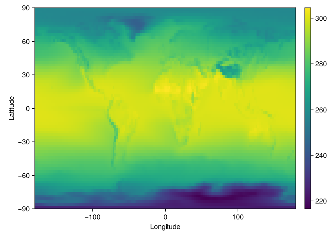

```julia
fig, ax, heat = heatmap(medians_kelvin[Variable=At("air_temperature_2m"), time=1]);
colorbar = Colorbar(fig[1,2], heat)
fig
```

## 5 Apply function with multiple output cubes

```julia
function norm(ts_out, mean_out, std_out, ts_in)
    x = filter(!ismissing, ts_in)

    tsshort = filter(!isnan,x)
    if isempty(tsshort)
        ts_out .= missing
        mean_out[] = missing
        std_out[] = missing
    else
        mean_out[] = mean(tsshort)
        std_out[] = std(tsshort)
        ts_out .= (ts_in .- mean_out[])./std_out[]
    end
end
```

```
norm (generic function with 1 method)
```

```julia
ts_norm, mean_ts, std_ts = xmap(norm, c ⊘ :time, output = (XOutput(c.time), XOutput(), XOutput()) )
```

```
(989×144×72×42 DiskArrayEngine.GMWOPResult{Union{Missing, Float32}, 4, DiskArrayEngine.GMDWop{4, Tuple{DiskArrayEngine.InputArray{DiskArrayTools.DiskArrayStack{Union{Missing, Float32}, 4, ZArray{Union{Missing, Float32}, 3, Zarr.BloscCompressor, Zarr.ConsolidatedStore{Zarr.ConsolidatedStore{Zarr.HTTP…
```

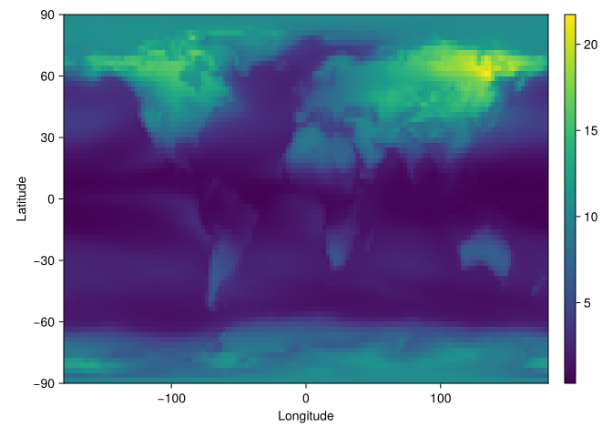

```julia
fig, ax, heat = heatmap(std_ts[Variable=At("air_temperature_2m"), time=1]);
colorbar = Colorbar(fig[1,2], heat)
fig
```

## 6 Apply function on moving window

```julia
function meanfilter(xout, xin)
    if ismissing(xin[2,2])
        xout .= missing
    else
    xout .= mean(skipmissing(xin))
    end
end
```

```
meanfilter (generic function with 1 method)
```

```julia
fig = Figure()
axorg = Axis(fig[1,1])
heatmap!(axorg, mean_ts[Variable=At("air_temperature_2m"), time=1])
```

```
Heatmap{Tuple{Vector{Float64}, Vector{Float64}, Matrix{Float32}}}
```

```julia
dlat = dims(c, :lat)
dlon = dims(c, :lon)
# This needs a better interface for within index space
latinterval = MovingIntervals(center=dlat.val, width=3*step(dlat), n=length(dlat), step=step(dlat))
loninterval = MovingIntervals(center=dlon.val, width=3*step(dlon), n=length(dlon), step=step(dlon))
meanwindows = windows(mean_ts, :lat=>latinterval, :lon=>loninterval)
```

```
Windowed array view with dimensions:
(↓ lon Sampled{Float64} [-178.75, …, 176.25] ForwardOrdered Irregular Points,
→ lat Sampled{Float64} [-88.75, …, 86.25] ForwardOrdered Irregular Points,
↗ time Sampled{IntervalSets.ClosedInterval{Dates.DateTime}} [1979-01-09T00:00:00 .. 2021-12-27T00:00:00] ForwardOrdered Irregular Intervals{Start},
⬔ Variables Categorical{String} ["sensible_heat", …, "snow_sublimation"] Unordered)
```

```julia
filteredmeans = xmap(meanfilter, meanwindows)

axmean = Axis(fig[2,1])
heatmap!(axmean, filteredmeans[Variable=At("air_temperature_2m"), time=1])
```

```
Heatmap{Tuple{Vector{Float64}, Vector{Float64}, Matrix{Float32}}}
```

## 7 Define new output dimensions

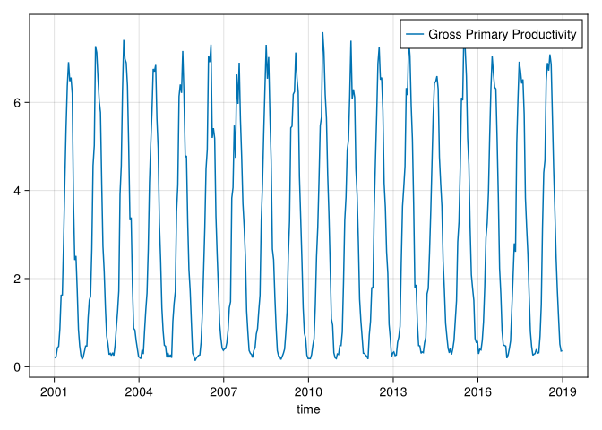

```julia
gpp = ds.gross_primary_productivity[
        time=Date(2001)..Date(2018,12,31),
        lon=Near(11.3464),lat=Near(46.4946)]
fig,ax, pl = lines(gpp, label= "Gross Primary Productivity")
fig
```

So far the function applied here were very simple statistics. Just to stress again, that we are running arbitrary Julia code here, so for example if we want to use some package for time series decomposition like `SignalDecomposition.jl`:

```julia
using SignalDecomposition
gpp_smooth , gpp_anomalies = readcubedata.(SignalDecomposition.decompose(lookup(gpp, :time), gpp, TimeAnomaly()))
```

```
(Union{Missing, Float32}[0.26431632, 0.28499743, 0.3646612, 0.5070831, 0.9533358, 1.4755393, 2.481591, 3.4215624, 4.6404815, 5.538373  …  6.3079944, 5.5141025, 4.30587, 3.3100874, 2.3342245, 1.5307907, 0.94750255, 0.5244855, 0.33817348, 0.28414476], Union{Missing, Float32}[-0.070323184, -0.045408547…
```

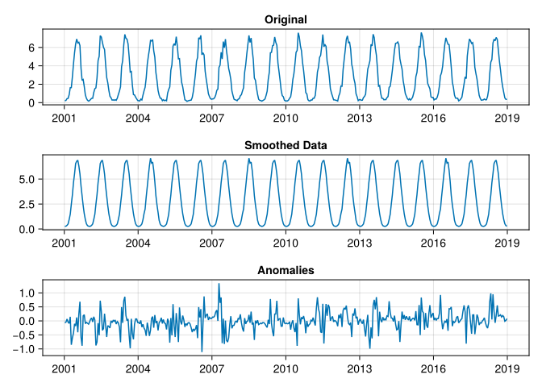

```julia
#function plot_stlres(t, org, stlres)
    fig = Figure()
    axorg = Axis(fig[1,1],title="Original")
    lines!(axorg, gpp, label="Original GPP")
    axsmooth = Axis(fig[2,1], title="Smoothed Data")
    lines!(axsmooth, gpp_smooth, label="GPP Smoothed")
    axanom = Axis(fig[3,1], title="Anomalies")
    lines!(axanom, gpp_anomalies, label="GPP Anomalies")
    #lines!(ax, gpp_smooth, label="GPP Smoothed")
    fig
```

In order to apply this over a full array we define the usual Trio: indims, outdims and the function to be applied. Here we create a new dimension for the output. This means that inside the function the input array `xin` is a vector of length `n_timesteps` and the output is a matrix of size `n_timesteps x 2`

```julia
function decompose_TS(xout, xin)
    any(isnan,xin) && return xout .= missing
    xsmooth, xanom = SignalDecomposition.decompose(xin)
    xout[:,1] = xsmooth
    xout[:,2] = xanom
end
```

```
decompose_TS (generic function with 1 method)
```

```julia
gpp_subset = ds.gross_primary_productivity[Variable=At("y"),
        time=Date(2001)..Date(2018,12,31)]
gpp_sub_decomposed = xmap(decompose_TS, gpp_subset⊘ :time, output = XOutput(gpp_subset.time, Dim{:Scale}(["Seasonal", "Anomalies"])))
```

```
┌ Warning: (DimensionalData.Dimensions.Dim{:Variable},) dims were not found in object.
└ @ DimensionalData.Dimensions ~/.julia/packages/DimensionalData/hv9KC/src/Dimensions/primitives.jl:852
```

```
┌ 414×2×144×72 YAXArray{Union{Missing, Float32}, 4} ┐
├───────────────────────────────────────────────────┴──────────────────── dims ┐
  ↓ time Sampled{Dates.DateTime} [Dates.DateTime("2001-01-09T00:00:00"), …, Dates.DateTime("2018-12-27T00:00:00")] ForwardOrdered Irregular Points,
  → Scale Categorical{String} ["Seasonal", "Anomalies"] ReverseOrdered,
  ↗ lon Sampled{Float64} -178.75:2.5:178.75 ForwardOrdered Regular Points,
  ⬔ lat Sampled{Float64} -88.75:2.5:88.75 ForwardOrdered Regular Points
├─────────────────────────────────────────────────────────────── loaded lazily ┤
  data size: 32.75 MB
└──────────────────────────────────────────────────────────────────────────────┘
```

You see that the resulting array is a 4-dimensional array including the newly created axis.